# comparison of traces with 16 processes

F. Suter

29/07/2014

In this document we want to study the evolution of the instruction rate for traces obtained from the execution of the LU NAS Parallle Benchmark with the same number of processes (16) but different data sizes (Classes A, B, and C).

Remark: a first analysis was made with ‘datasets/td.lu.B.16.comp.4b.III’ and ‘datasets/ti.lu.B.16.comp.4c.V’. It led to some “anormal” results, in a sens that class B was executed slower than class A. Some checks shown that the timing were bigger than they should have been.

## Init

```r
library(ggplot2)
setwd('~/SVN/Anshul/ScalaTrace-TI')

td.a.16.comp.4b.I<-read.table('datasets/td.lu.A.16.comp.4b.I', header=TRUE)
ti.a.16.comp.4c.I<-read.table('datasets/ti.lu.A.16.comp.4c.I', header=TRUE)

td.b.16.comp.4b.I<-read.table('datasets/td.lu.B.16.comp.4b.I', header=TRUE)
ti.b.16.comp.4c.I<-read.table('datasets/ti.lu.B.16.comp.4c.I', header=TRUE)

td.c.16.comp.4b.I<-read.table('datasets/td.lu.C.16.comp.4b.I', header=TRUE)
ti.c.16.comp.4c.I<-read.table('datasets/ti.lu.C.16.comp.4c.I', header=TRUE)
```

## Preparing the datasets

We first modify the datasets for each class by replacing the original (avg, min, max) per block of the Timed trace (td) by the average time (COMP.4b.avg, in seconds) and the average number of instructions (COMP.4c.avg, after correction) per block.

Then we add new columns:

- rate: the instruction rate of an event, i.e. the #instructions divided by the time, or COMP.4.c / COMP.4.b
- time: an estimation of the time taken by an event (number of occurences * avg time)
- inst: an estimation of the number of instruction of an event (number of occurences * avg #instructions)
- time_percent: the relative time contribution of an event (in percentage)
- inst_percent: the relative instruction contribution of an event (in percentage)

Note: the last two columns might be biased as all the processes do not execute all the events (depends on the rank lists)

```r
a.16<-cbind(td.a.16.comp.4b.I[,1:4],
            td.a.16.comp.4b.I$avg/1e6,
            ti.a.16.comp.4c.I$avg*1e3)

colnames(a.16)[5:6]<-c("COMP.4b.avg", "COMP.4c.avg")
a.16$rate <- a.16$COMP.4c.avg / a.16$COMP.4b.avg
a.16$time <- a.16$events * a.16$COMP.4b.avg
a.16$inst <- a.16$events * a.16$COMP.4c.avg
a.total_time = sum(a.16$time)
a.total_inst = sum(a.16$inst)

a.16$time_percent <- round((a.16$time*100)/a.total_time, digits = 2)
a.16$inst_percent <- round((a.16$inst*100)/a.total_inst, digits = 2)

b.16<-cbind(td.b.16.comp.4b.I[,1:4],
            td.b.16.comp.4b.I$avg/1e6,
            ti.b.16.comp.4c.I$avg*1e3)

colnames(b.16)[5:6]<-c("COMP.4b.avg", "COMP.4c.avg")
b.16$rate <- b.16$COMP.4c.avg / b.16$COMP.4b.avg
b.16$time <- b.16$events * b.16$COMP.4b.avg
b.16$inst <- b.16$events * b.16$COMP.4c.avg
b.total_time = sum(b.16$time)
b.total_inst = sum(b.16$inst)
b.16$time_percent <- round((b.16$time*100)/b.total_time, digits = 2)
b.16$inst_percent <- round((b.16$inst*100)/b.total_inst, digits = 2)

c.16<-cbind(td.c.16.comp.4b.I[,1:4],
            td.c.16.comp.4b.I$avg/1e6,
            ti.c.16.comp.4c.I$avg*1e3)

colnames(c.16)[5:6]<-c("COMP.4b.avg", "COMP.4c.avg")

c.16$rate <- c.16$COMP.4c.avg / c.16$COMP.4b.avg
c.16$time <- c.16$events * c.16$COMP.4b.avg
c.16$inst <- c.16$events * c.16$COMP.4c.avg
c.total_time = sum(c.16$time)
c.total_inst = sum(c.16$inst)
c.16$time_percent <- round((c.16$time*100)/c.total_time, digits = 2)
c.16$inst_percent <- round((c.16$inst*100)/c.total_inst, digits = 2)
```

Compute rough estimations of the average processing rate for each class by dividing the sum of instruction numbers by the sum of execution time

```r
times <- c(a.total_time,b.total_time,c.total_time)
insts <- c(a.total_inst,b.total_inst,c.total_inst)
rates <- insts/times
rates
```

```
## [1] 3.975e+09 4.112e+09 4.186e+09
```

We note a slight increases of the rate as the handle data size grows. Check the evolution of times and instructions sums to see whether it matches the data size increase (roughly multiplied by 4).

```r
evol_time = c(times[2]/times[1], times[3]/times[2])
evol_inst = c(insts[2]/insts[1], insts[3]/insts[2])
evol_time
```

```
## [1] 3.779 3.960
```

```r
evol_inst
```

```
## [1] 3.910 4.031
```

The evolution of the number of instructions is very consistent with the evolution of data size (as expected). A bit worse for time, but rather consistent though.

## Comparing the traces

Give a first try by binding the dataframes by rows. This doesn’t allow us to verify that events at the same line are actually the same (evenID-opcode-subblock). We might consider a binding by columns at some point.

```r
df<-rbind(data.frame(a.16, class='A-16', rows=1:nrow(a.16)),
          data.frame(b.16, class='B-16', rows=1:nrow(b.16)),
          data.frame(c.16, class='C-16', rows=1:nrow(c.16)))
```

## Plotting stuff

Start by plotting the instruction rate per event, factoring by class and having a bigger point if the event is an important contributor in terms of time.

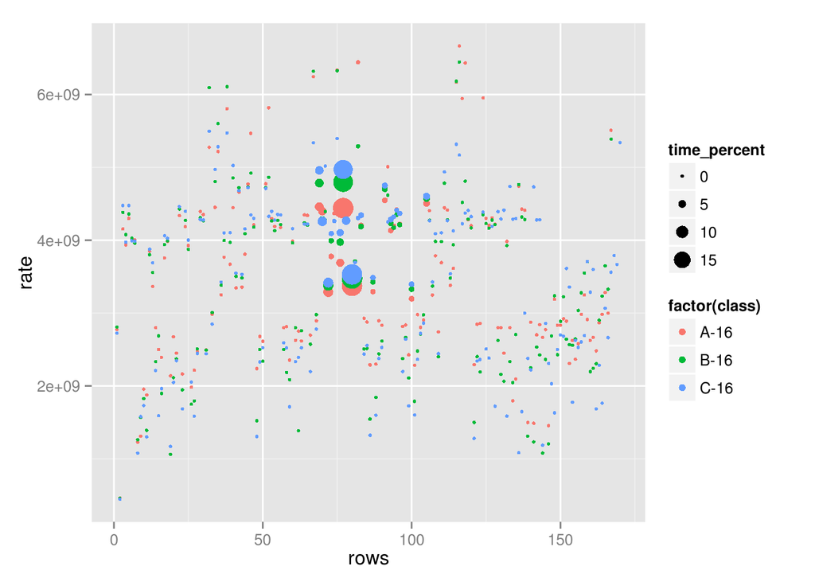

```r
ggplot(df, aes(x=rows, y=rate, color=factor(class),size=time_percent)) +
  geom_point()
```

Very small contributions are still displayed, get rid of them to increase clarity. Let start with a threshold at 0.01 % (df2) and be more selective with a second threshold at 1% (df3).

```r
df2 = df[df$time_percent>0.0,]
df3 = df[df$time_percent>=1,]
```

## Analysis of contributions greater than 0.01%

Same graph as before but with less points.

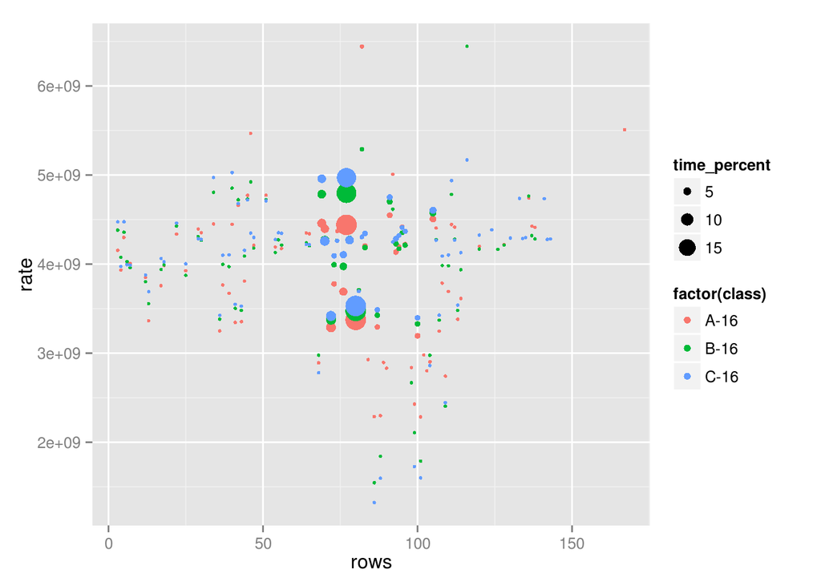

```r
ggplot(df2, aes(x=rows, y=rate, color=factor(class),size=time_percent)) +
  geom_point()
```

The biggest contributors look to be in the middle part (from row 55 to 105), zoom in.

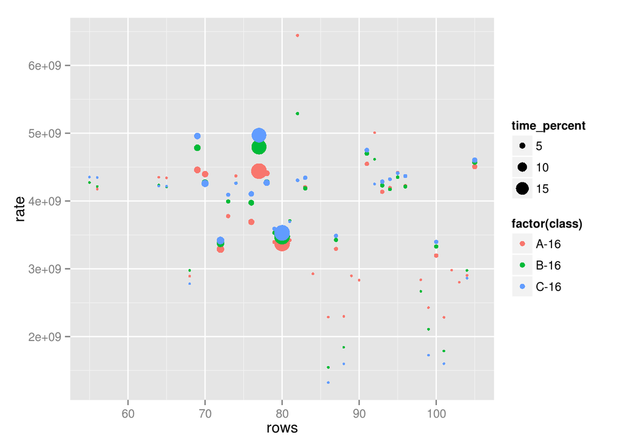

```r
ggplot(df2, aes(x=rows, y=rate, color=factor(class),size=time_percent)) +
  geom_point() +xlim(55,105)
```

Let see what a line shows. Remove the sizing then and stops at row 123 (not the same events after)

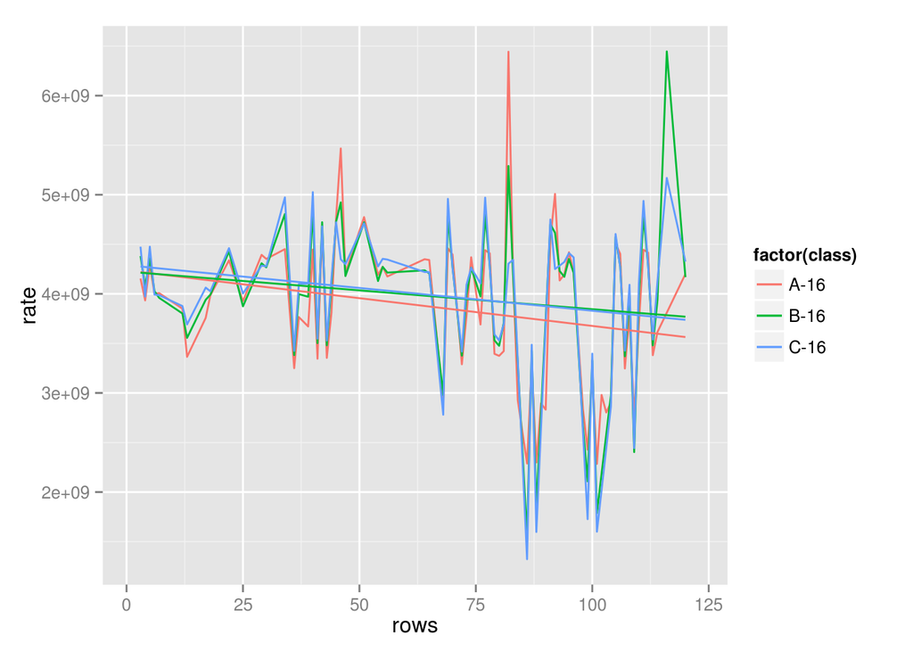

```r
ggplot(df2, aes(x=rows, y=rate, color=factor(class))) +
  geom_line() + xlim(1, 123) + geom_smooth(method="lm", se=FALSE)
```

## Analysis of contribution greater than 1%

We plot the same graphs but with the df3 dataframe.

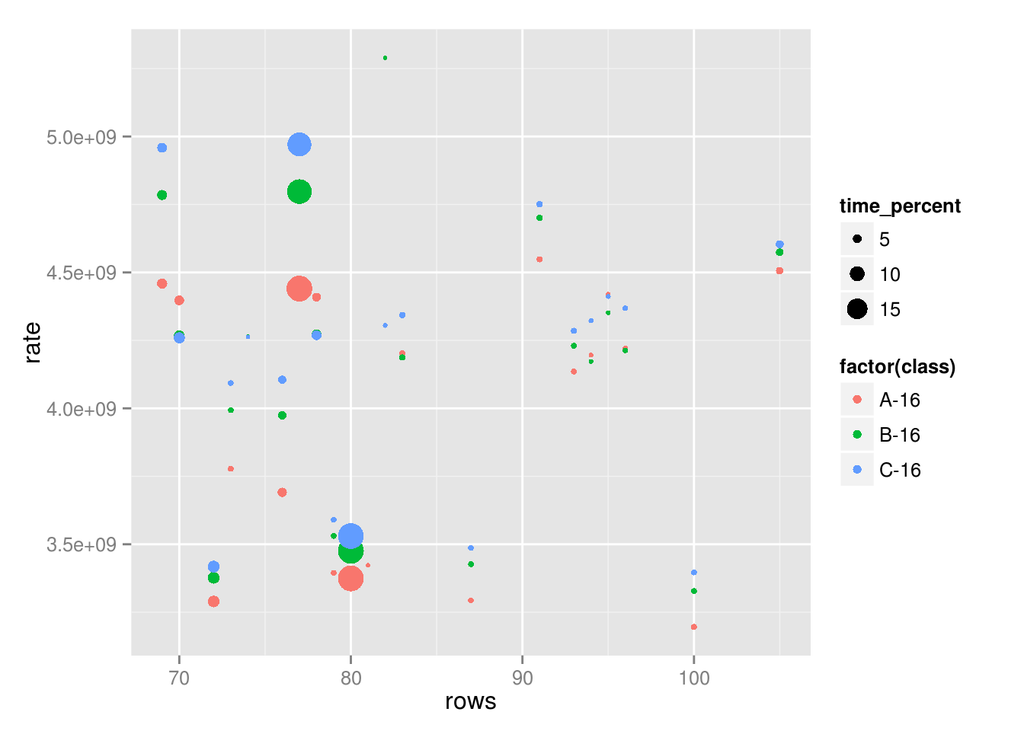

```r
ggplot(df3, aes(x=rows, y=rate, color=factor(class),size=time_percent)) +
  geom_point()
```

There is no more need to zoom in, this threshold allows us to focus directly on the main part of the benchmark (i.e. the iterative computation of SSOR)

Let see what a line shows for this subset of points

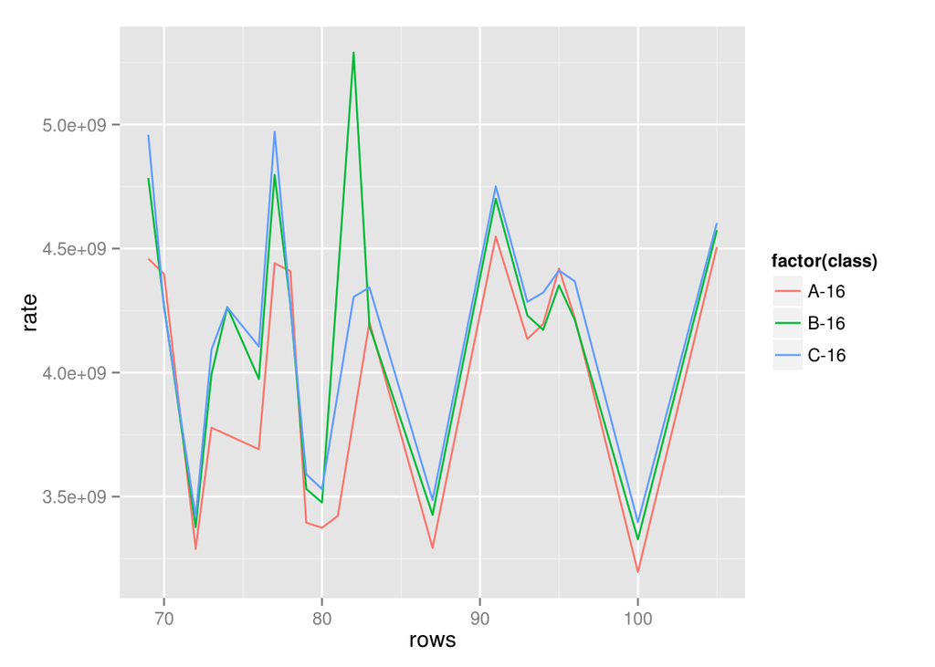

```r
ggplot(df3, aes(x=rows, y=rate, color=factor(class))) +
  geom_line()
```

The three lines look very close. Let recompute rates only on this subset of “big contributors” and compare them to those obtained for the whole traces.

```r
a.big_time = sum (df3[df3$class=="A-16",]$time)
b.big_time = sum (df3[df3$class=="B-16",]$time)
c.big_time = sum (df3[df3$class=="C-16",]$time)
a.big_inst = sum (df3[df3$class=="A-16",]$inst)
b.big_inst = sum (df3[df3$class=="B-16",]$inst)
c.big_inst = sum (df3[df3$class=="C-16",]$inst)
big_times <- c(a.big_time, b.big_time, c.big_time)
big_insts <- c(a.big_inst, b.big_inst, c.big_inst)
big_rates <- big_insts/big_times
big_rates
```

```
## [1] 3.955e+09 4.121e+09 4.194e+09
```

```r
rates
```

```
## [1] 3.975e+09 4.112e+09 4.186e+09
```

There is only a small difference, which may confirm that the average rate is mainly defined by these few events.

## Is the average rate so bad?

Let try something completely different. Focus on class B, and see for each event what is the difference in time if we apply average rate, compare to the measure time.

To do so, we first add a new column that corresponds to a “would-be” simulated, i.e., the global number of instructions of an event executed at the average rate.

```r
b.avg_rate = b.total_inst/b.total_time
b.16$sim_time <- b.16$inst/b.avg_rate
```

Then we plot, for each event both approximated time (avg time * number of occurences) and the simulated time.

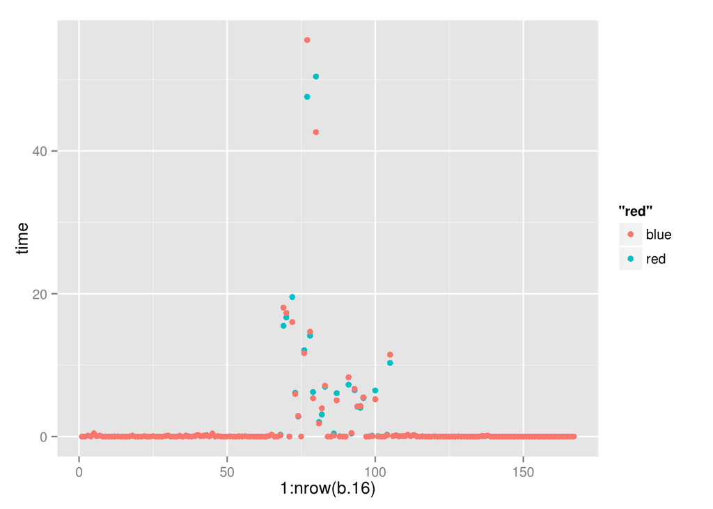

```r
ggplot(b.16, aes(x=1:nrow(b.16))) + geom_point(aes(y=time, color="red"))+
  geom_point(aes(y=sim_time, color="blue"))
```

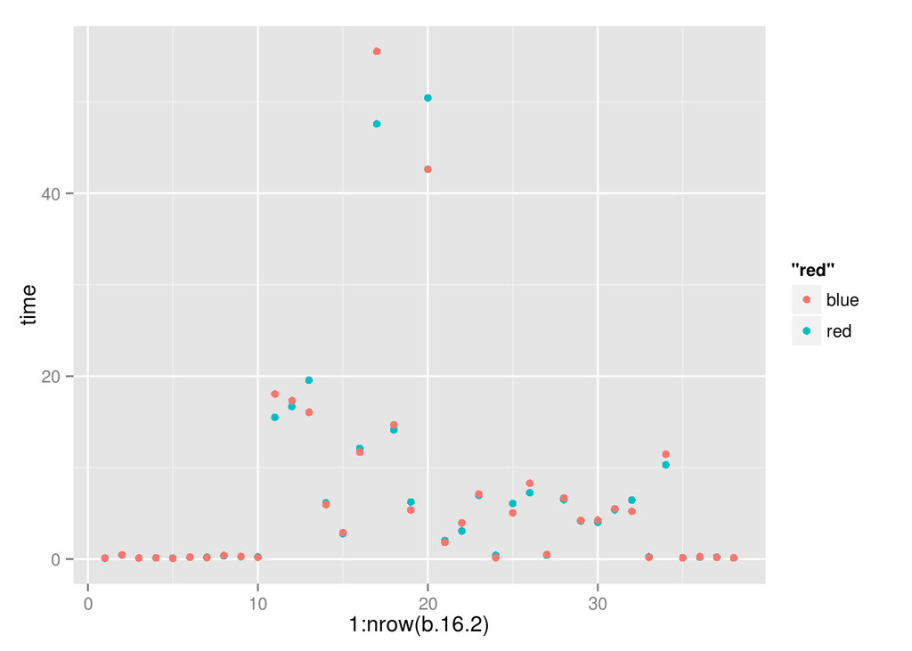

```r
b.16.2 = b.16[b.16$time>0.1,]
ggplot(b.16.2, aes(x=1:nrow(b.16.2))) + geom_point(aes(y=time, color="red"))+
  geom_point(aes(y=sim_time, color="blue"))
```

Compute the differences between times and simulated times and plot

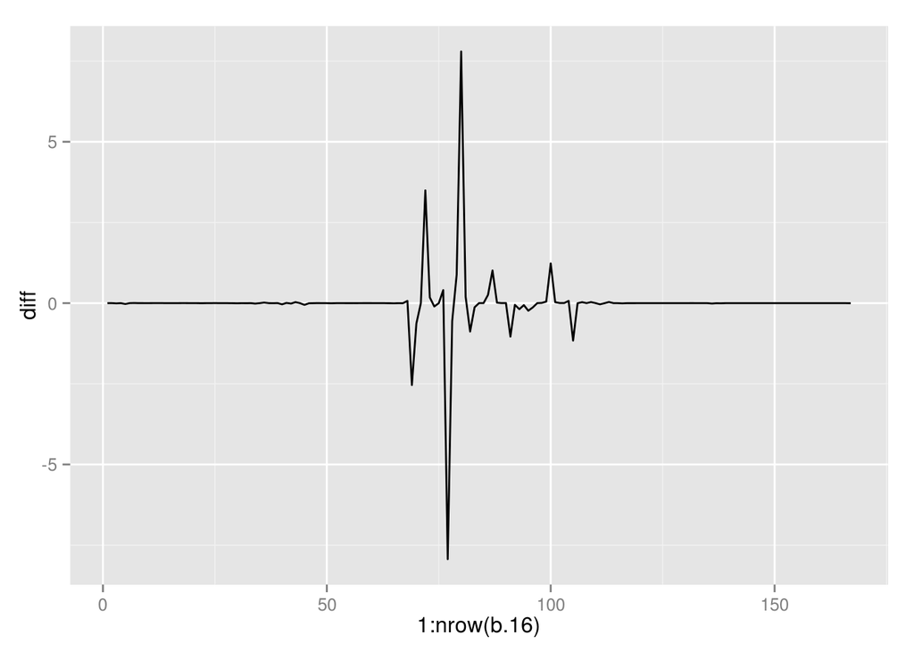

```r
b.16$diff <- b.16$time-b.16$sim_time
ggplot(b.16, aes(x=1:nrow(b.16), y=diff)) + geom_line()
```

There are only a few for which using the average rate leads to bad prediction, but it seems to compensate. look at the summary of diff and at the overall sum:

```r
summary(b.16$diff)
```

```
##    Min. 1st Qu.  Median    Mean 3rd Qu.    Max.
##  -7.930  -0.001   0.000   0.000   0.001   7.800
```

```r
sum(b.16$diff)
```

```
## [1] -5.431e-15
```

```r
b.total_time
```

```
## [1] 259.2
```

```r
sum(b.16$sim_time)
```

```
## [1] 259.2
```

In the end, we have the same time!

Do we have the same behavior for all the classes? do something similar on df2 (the dataframe that merges all data.). Add the missing columns to the dataframes for classes A and C and bind them again in a new dataframe (df4)

```r
a.avg_rate = a.total_inst/a.total_time
c.avg_rate = c.total_inst/c.total_time
a.16$sim_time <- a.16$inst/a.avg_rate
c.16$sim_time <- c.16$inst/c.avg_rate

a.16$diff <- a.16$time-a.16$sim_time
c.16$diff <- c.16$time-c.16$sim_time

df4<-rbind(data.frame(a.16, class='A-16', rows=1:nrow(a.16)),
           data.frame(b.16, class='B-16', rows=1:nrow(b.16)),
           data.frame(c.16, class='C-16', rows=1:nrow(c.16)))
```

Do we have the same skipes for all classes?

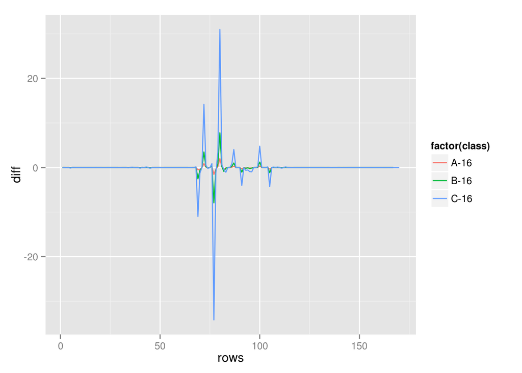

```r
ggplot(df4, aes(x=rows, y=diff, color=factor(class))) + geom_line()
```

Yes! The same but zooming on where the spikes are:

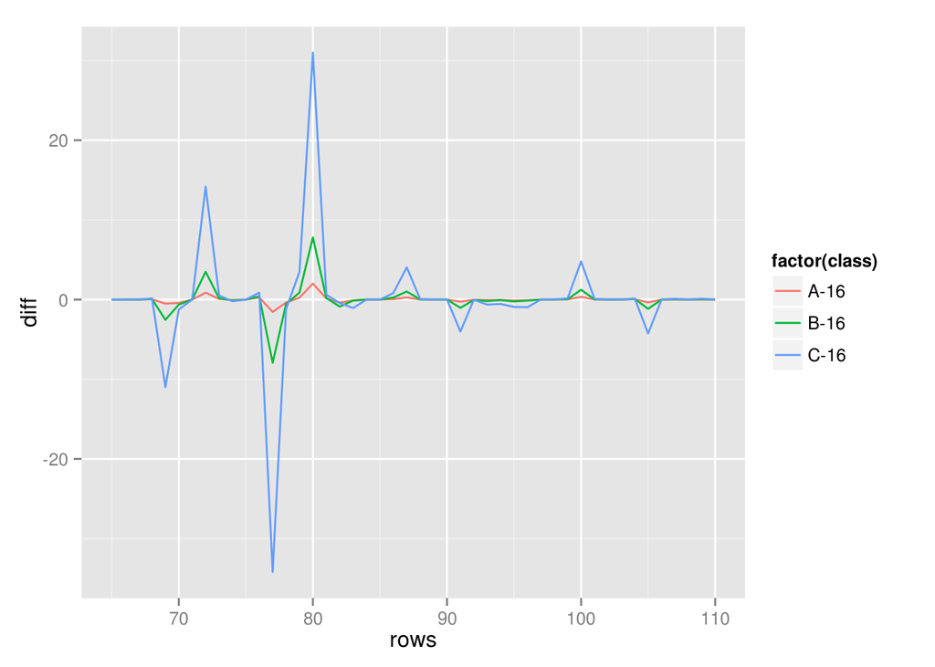

```r
ggplot(df4, aes(x=rows, y=diff, color=factor(class))) + geom_line() +xlim(65,110)
```

The only thing that changes as we increase the size of the problem is the amplitude of the spikes, but they are at the exact same place and seem to compensate themselves. We can verify this by computing the sums of the differences:

```r
diffs <- c(sum(a.16$diff), sum(b.16$diff), sum(c.16$diff))
diffs
```

```
## [1]  7.036e-15 -5.431e-15  6.323e-14
```

Very accurate indeed!